# EDS-230: Assignment 1

- Show All Code
- Hide All Code
- View Source

Author

Affiliation

Oksana Protsukha

Master of Environmental Data Science Program

Published

April 14, 2025

#### Project repository

https://github.com/oksanaprotsukha/almond_yields_model

## Objective

Implement a simple model of almond yield anomaly response to climate.

## Implementation

The transfer function used in the model is based on the equation for almond yields from the Lobell et al. 2006 paper [1]:

$$Y = -0.015T_{n,2} - 0.0046T_{n,2}^2 - 0.07P_1 + 0.0043P_1^2 + 0.28 \quad, R^2_{\text{adj}} = 0.88$$

$$T_{n,2}: \text{Temperature in °C.}$$

$$P_1: \text{Precipitation in mm.}$$

$$Y: \text{Yield in tons per hectare (t/ha).}$$

**Transfer Function**:

**Inputs**: daily times series of minimum and maximum daily temperatures, and precipitation.  
**Outputs**: maximum, minimum and mean yield anomaly for an input time series.

## Almond Yield Model Diagram

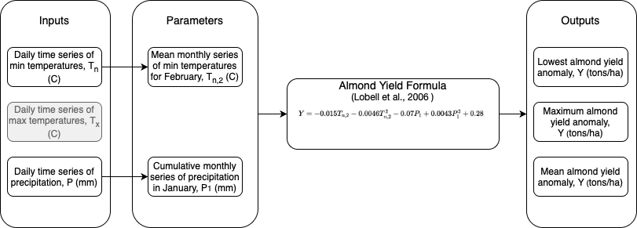

Almond Yield Model

### Considerations

The model uses climate data from a specific month, whereas the data file contains daily climate data. To maintain model flexibility, the almond yield function is designed to accept pre-processed parameters. Specifically, the daily time series in the input data must be transformed outside the function. This approach separates the function’s logic from the structure of the input dataframe.

## Data

The `clim.txt` file contains the following columns:

- **Day**: The day the climate observation was made.
- **Month**: The month the climate observation was made.
- **Year**: The year the climate observation was made.
- **Wy (Water Year)**: The water year corresponding to the observation.

The following columns represent the climate observations for each day:

- **tmax_c**: Maximum daily temperature in °C.
- **tmin_c**: Minimum daily temperature in °C.
- **precip**: Precipitation on that day in mm.

## Import and preprocess data

```r
# import data

root <- here()
data <- "data/clim.txt"

df <- read.delim(data, sep = "")

# load the script that calculates almond yield anomaly response to climate
source(here("R/crop_yield_climate_sensitivity.R"))
```

```r
# pre-process data: convert raw inputs into the function parameters
t_min_feb <- df %>%
  filter(month == 2) %>%
  group_by(year) %>%
  summarise(mean_min_temp = mean(tmin_c)) %>%
  pull(mean_min_temp)

t_max_feb <- df %>%
  filter(month == 2) %>%
  group_by(year) %>%
  summarise(mean_max_temp = mean(tmax_c)) %>%
  pull(mean_max_temp)

p_jan <- df %>%
  filter(month == 1) %>%
  group_by(wy) %>%
  summarise(sum_precip = sum(precip)) %>%
  pull(sum_precip)
```

## Calculate almond yield

```r
# call almond_yield function
crop_yield_climate_sensitivity(t_min_feb, p_jan)
```

```
$min_crop_yield
[1] -0.35

$max_crop_yield
[1] 1919.98

$mean_crop_yield
[1] 181.44
```

### Citations

[1] Lobell DB, Field CB, Cahill KN, Bonfils C. Impacts of future climate change on California perennial crop yields: Model projections with climate and crop uncertainties. Global Environmental Change. 2006;16(2): 227-239. doi:10.1016/j.gloenvcha.2006.10.004.